# exploration

For this project, I began with microplastic count data for various sample sites, variables including site, watershed, latitude, longitude, and a_count and b_count. So far, I have obtained the following additional data:

- local land cover based on coordinates converted to census FIPS codes, using NGIS data
- bacterial data from corresponding UOWN sample dates/sites
- location population levels by zip code, converted from lat/long and joined with census data.

In this document, I will explore relationships between some of these variables.

Quantities of main interest:

- particles per liter of microplastics
- season/sample date
- population level
- proximity to water reclamation facility effluent
- bacteria levels at corresponding samples sites/dates

# load packages and data

```r
library(dplyr) #for data processing
library(here) #to set paths
library(tidyverse)
```

```r
library(ggplot2)
library(GGally) #for producing correlation matrices
library(gridExtra) #
library(gtsummary)


#path to data
data_location <- here::here("data","processed_data","mpwrfcombo.rds")

#load data
mpdata <- readRDS(data_location)
```

Let’s start with some summary statistics. We want to see the overall summary of microplastic concentration - mean, median, range, etc.

# Summary statistics

```r
summary <- summary(mpdata)
summary
```

```
##      site            watershed              lat             long
##  Length:109         Length:109         Min.   :33.86   Min.   :-83.55
##  Class :character   Class :character   1st Qu.:33.89   1st Qu.:-83.45
##  Mode  :character   Mode  :character   Median :33.93   Median :-83.42
##                                        Mean   :33.93   Mean   :-83.43
##                                        3rd Qu.:33.96   3rd Qu.:-83.39
##                                        Max.   :34.01   Max.   :-83.33
##
##   particles_l          date                year          month
##  Min.   :  16.67   Length:109         Min.   :2020   Min.   : 2.000
##  1st Qu.:  46.67   Class :character   1st Qu.:2021   1st Qu.: 2.000
##  Median :  66.67   Mode  :character   Median :2021   Median : 4.000
##  Mean   : 104.39                      Mean   :2021   Mean   : 5.826
##  3rd Qu.: 106.67                      3rd Qu.:2021   3rd Qu.: 7.000
##  Max.   :1193.33                      Max.   :2021   Max.   :11.000
##
##   visual_score   turbidity.ntu    temperature.c     e.coli.cfu
##  Min.   :15.00   Min.   : 1.220   Min.   : 7.00   Min.   :  35.0
##  1st Qu.:34.00   1st Qu.: 4.223   1st Qu.:13.90   1st Qu.: 155.0
##  Median :39.00   Median : 8.160   Median :15.80   Median : 235.0
##  Mean   :38.77   Mean   : 8.770   Mean   :15.88   Mean   : 436.8
##  3rd Qu.:44.00   3rd Qu.:12.325   3rd Qu.:20.30   3rd Qu.: 515.0
##  Max.   :54.00   Max.   :23.600   Max.   :26.00   Max.   :4000.0
##  NA's   :10      NA's   :5        NA's   :8       NA's   :6
##     quarter          FIPS             population        wrf
##  Min.   :1.000   Length:109         Min.   : 1849   Length:109
##  1st Qu.:1.250   Class :character   1st Qu.: 4325   Class :character
##  Median :2.000   Mode  :character   Median : 6103   Mode  :character
##  Mean   :2.462                      Mean   : 6930
##  3rd Qu.:3.000                      3rd Qu.: 7447
##  Max.   :4.000                      Max.   :13503
##  NA's   :3
##       dist
##  Min.   : 1390
##  1st Qu.: 3026
##  Median :10889
##  Mean   : 8618
##  3rd Qu.:12612
##  Max.   :14905
##
```

```r
#save table
saveRDS(summary, file = here("results", "summarytable.rds"))
```

Our observations can be categorized by sample date, since there were four different sample events that occurred. Let’s see if there is any temporal relationship in the microplastic concentrations.

# MP concentration by season

```r
summary(mpdata)
```

```
##      site            watershed              lat             long
##  Length:109         Length:109         Min.   :33.86   Min.   :-83.55
##  Class :character   Class :character   1st Qu.:33.89   1st Qu.:-83.45
##  Mode  :character   Mode  :character   Median :33.93   Median :-83.42
##                                        Mean   :33.93   Mean   :-83.43
##                                        3rd Qu.:33.96   3rd Qu.:-83.39
##                                        Max.   :34.01   Max.   :-83.33
##
##   particles_l          date                year          month
##  Min.   :  16.67   Length:109         Min.   :2020   Min.   : 2.000
##  1st Qu.:  46.67   Class :character   1st Qu.:2021   1st Qu.: 2.000
##  Median :  66.67   Mode  :character   Median :2021   Median : 4.000
##  Mean   : 104.39                      Mean   :2021   Mean   : 5.826
##  3rd Qu.: 106.67                      3rd Qu.:2021   3rd Qu.: 7.000
##  Max.   :1193.33                      Max.   :2021   Max.   :11.000
##
##   visual_score   turbidity.ntu    temperature.c     e.coli.cfu
##  Min.   :15.00   Min.   : 1.220   Min.   : 7.00   Min.   :  35.0
##  1st Qu.:34.00   1st Qu.: 4.223   1st Qu.:13.90   1st Qu.: 155.0
##  Median :39.00   Median : 8.160   Median :15.80   Median : 235.0
##  Mean   :38.77   Mean   : 8.770   Mean   :15.88   Mean   : 436.8
##  3rd Qu.:44.00   3rd Qu.:12.325   3rd Qu.:20.30   3rd Qu.: 515.0
##  Max.   :54.00   Max.   :23.600   Max.   :26.00   Max.   :4000.0
##  NA's   :10      NA's   :5        NA's   :8       NA's   :6
##     quarter          FIPS             population        wrf
##  Min.   :1.000   Length:109         Min.   : 1849   Length:109
##  1st Qu.:1.250   Class :character   1st Qu.: 4325   Class :character
##  Median :2.000   Mode  :character   Median : 6103   Mode  :character
##  Mean   :2.462                      Mean   : 6930
##  3rd Qu.:3.000                      3rd Qu.: 7447
##  Max.   :4.000                      Max.   :13503
##  NA's   :3
##       dist
##  Min.   : 1390
##  1st Qu.: 3026
##  Median :10889
##  Mean   : 8618
##  3rd Qu.:12612
##  Max.   :14905
##
```

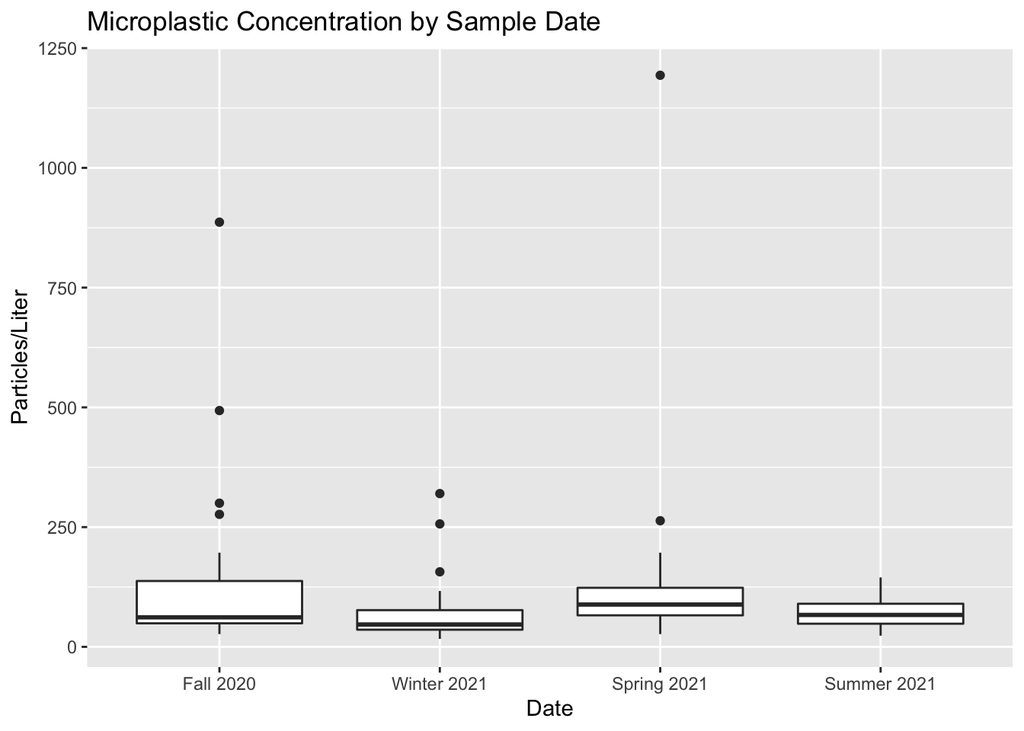

```r
# view particles/L by season

mpdata$date <- factor(mpdata$date , levels=c("nov_20", "feb_21", "apr_21", "july_21")) #reorder dates to appear chronologically

# make boxplot for microplastic concentration by season
p1 <- mpdata %>% ggplot(aes(x = date, y = particles_l)) +
  geom_boxplot(aes()) +
  labs(title = "Microplastic Concentration by Sample Date", x = "Date", y = "Particles/Liter") +
  scale_x_discrete(labels=c("Fall 2020",
                            "Winter 2021",
                            "Spring 2021",
                            "Summer 2021"))

plot(p1)
```

```r
#save figure
ggsave(filename = here("results","concentrationbydate.png"), plot=p1)
```

One of our main hypothesized predictors is population. Population size is a suppossed proxy for anthropogenic impact. We want to examine if microplastic levels increase in areas (census tracts) with greater populations.

For all samples, let’s compare microplastic level and local population.

# MP level vs population

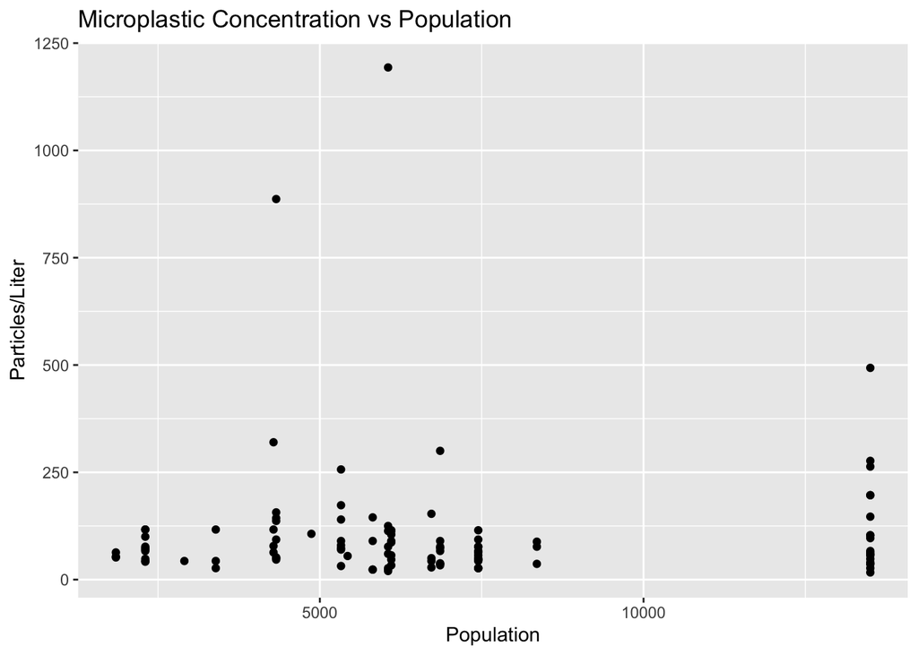

```r
p2 <- mpdata %>% ggplot(aes(x = population, y = particles_l)) + geom_point() +
  labs(title = "Microplastic Concentration vs Population", x = "Population", y = "Particles/Liter")

plot(p2)
```

```r
#save figure
ggsave(filename = here("results","particlesvpop.png"), plot=p2)
```

I’m not seeing any obvious relationships here. Also, population values are appearing discrete/in clusters rather than continous since there are a limited number of census tracts codes in the study area, and population was based on census tract.

Another way to visualize microplastic concentration vs population may be to log transform the microplastic levels. This would normalize the data, and the log transformation method has been used in previously published studies that analyze microplastic levels.

# particles vs population with log transformation

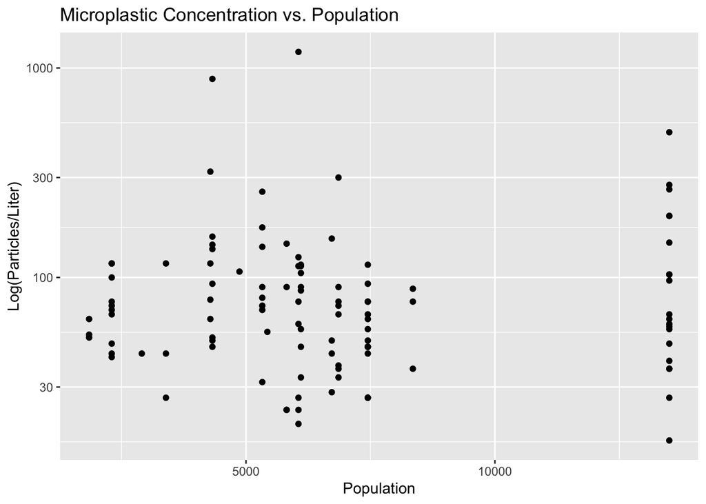

```r
p3 <- mpdata %>% ggplot(aes(x = population, y = particles_l)) +
  geom_point() +
  scale_y_continuous(trans='log10') +
  labs(title = "Microplastic Concentration vs. Population", x = "Population", y = "Log(Particles/Liter)")

plot(p3)
```

```r
#save figure
figure_file = here("results","logparticlesvpop.png")
ggsave(filename = figure_file, plot=p3)
```

This gives us a plot that is a little nicer to look at, but we still don’t see a clear relationship between micrplastic level and local population.

Another potential predictor is e.coli colony forming units. Similar to population count, e.coli levels may be a proxy for human impact/nearby pollution sources. We want to see if there is a relationship between microplastic pollution and bacteria levels at the sample sites.

# plot e.coli.cfu vs particles_l

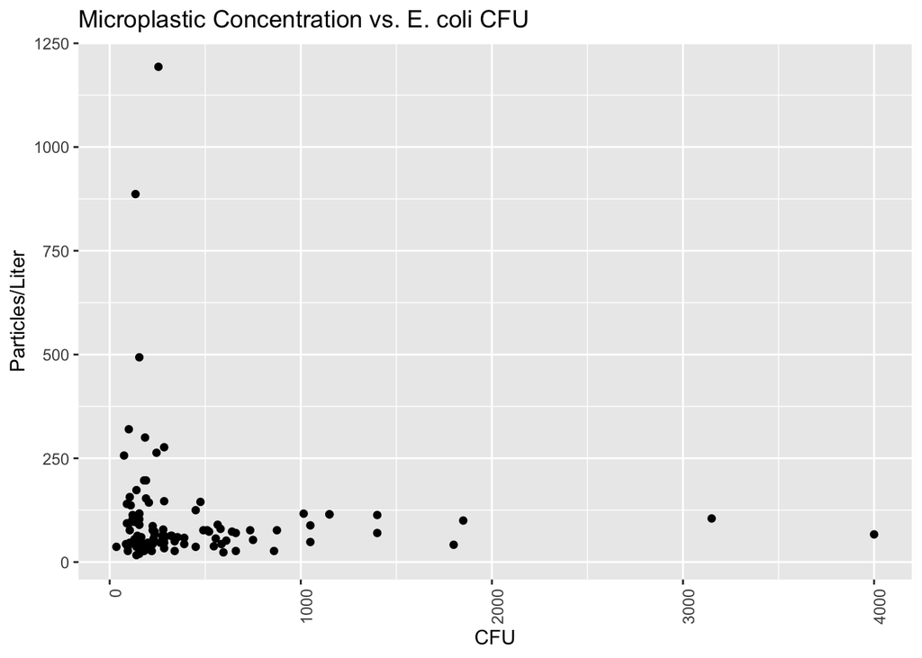

```r
p4 <- mpdata %>% ggplot(aes(x = e.coli.cfu, y = particles_l)) +
  geom_point() +
  theme(axis.text.x = element_text(angle = 90, hjust=1)) +
  labs(title = "Microplastic Concentration vs. E. coli CFU", x = "CFU", y = "Particles/Liter")

plot(p4)
```

```r
#save figure
figure_file = here("results","mpvcfu.png")
ggsave(filename = figure_file, plot=p4)
```

Again, no obvious relationships here. We also see some pretty low values in this plot. How about if we looked with a logarithmic scale? Log transformation is often used for bacterial data, and can also be used with microplastic levels.

# log(MP) vs log(CFU) log transformed

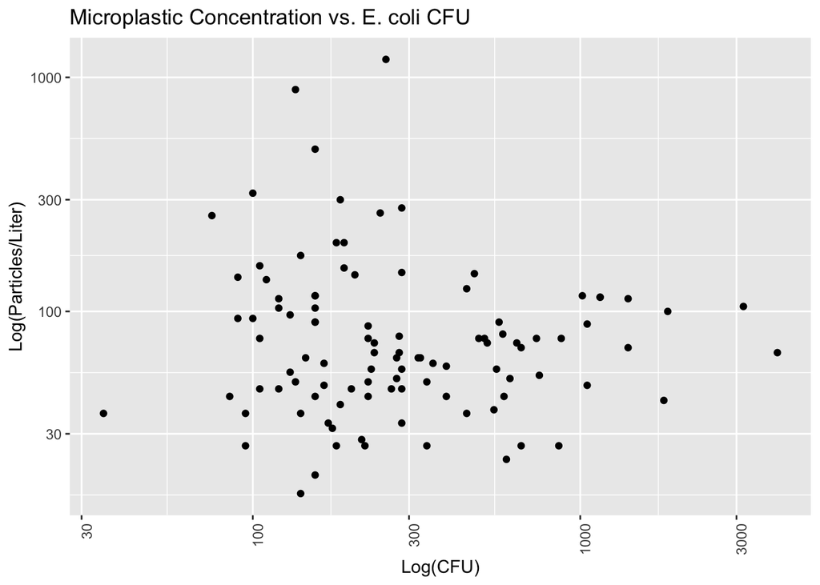

```r
p5 <- mpdata %>% ggplot(aes(x = e.coli.cfu, y = particles_l)) +
  geom_point() +
  theme(axis.text.x = element_text(angle = 90, hjust=1)) +
  scale_x_continuous(trans='log10') +
  scale_y_continuous(trans='log10') +
  labs(title = "Microplastic Concentration vs. E. coli CFU", x = "Log(CFU)", y = "Log(Particles/Liter)")

plot(p5)
```

```r
#save figure
figure_file = here("results","logmpvcfu.png")
ggsave(filename = figure_file, plot=p5)
```

The log transformation may make these values easier to work with. Still no clear relationships, however.

Now, let’s look at overall distribution of MP levels.

# Distribution of MP concentration

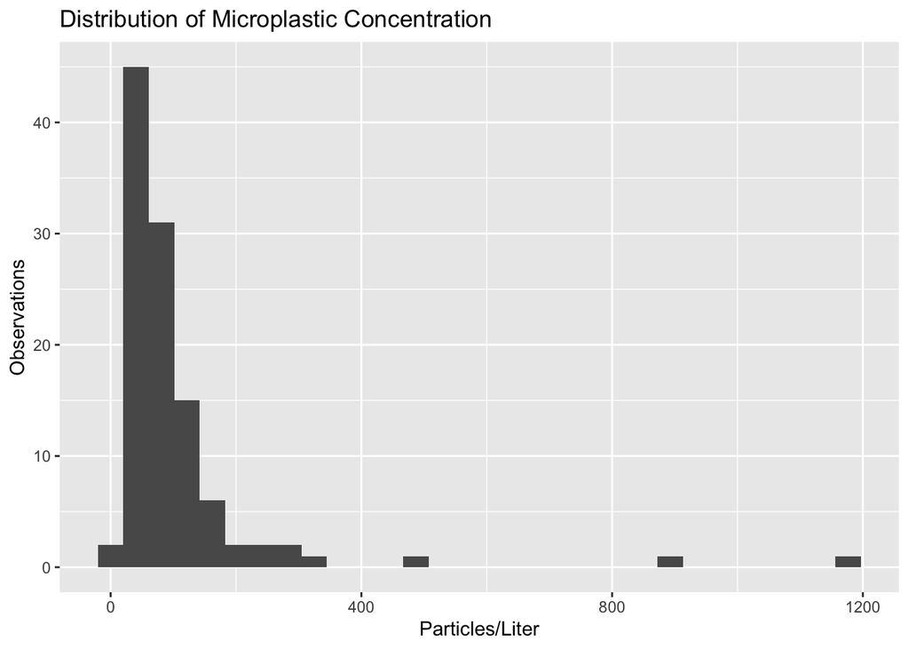

```r
mpdata %>% ggplot(aes(x = particles_l)) + geom_histogram() +
  labs(title = "Distribution of Microplastic Concentration", x = "Particles/Liter", y = "Observations")
```

Most observations fall below 300 particles/L, with a few large outliers.

We have some large outliers that make it harder to view the exact distribution of the lower values. Let’s filter out the outliers for a moment.

# Distribution of MP concentration without outliers

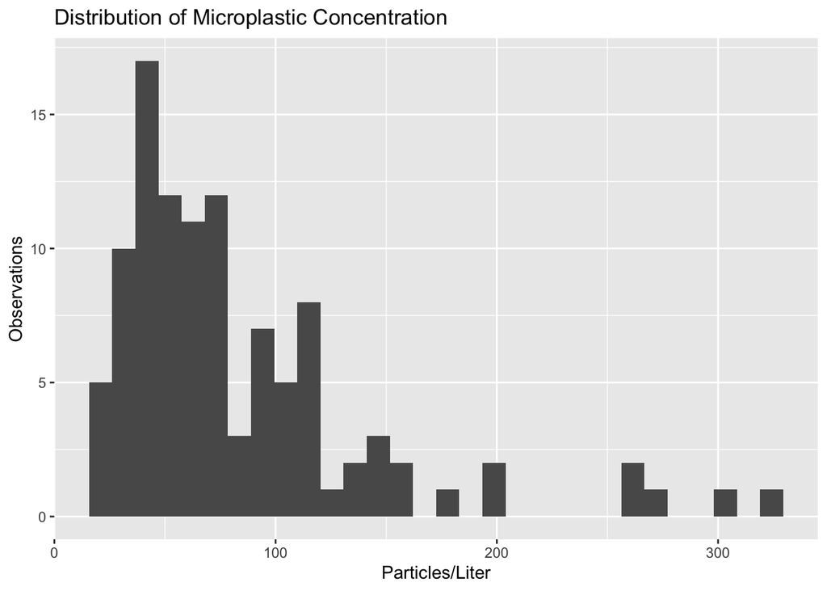

```r
p6 <- mpdata %>% filter(particles_l < 400) %>% ggplot(aes(x = particles_l)) + geom_histogram() +
  labs(title = "Distribution of Microplastic Concentration", x = "Particles/Liter", y = "Observations")

plot(p6)
```

```r
#save figure
figure_file = here("results","distribution.png")
ggsave(filename = figure_file, plot=p6)
```

In this graph, we can more clearly see that most levels fall below 100 particles per liter.

Another way to look at relationships among predictors and outcome is through correlation matrices. These allow us to view multiple relationships at once.

# correlation matrices

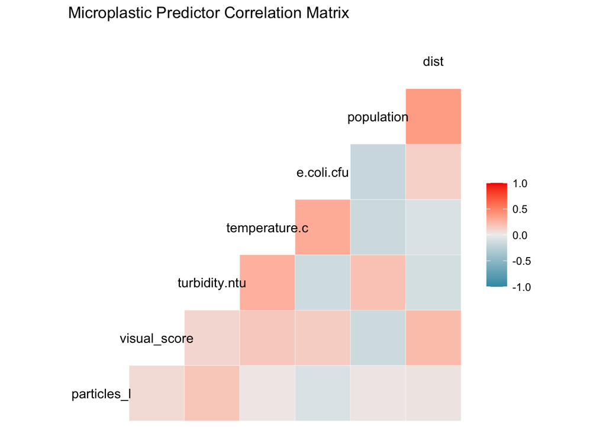

```r
#subsetting data to keep only variables we are interested in for the corr plot
mpdatacorr <- mpdata %>% select(-"quarter",
                                -"month",
                                -"lat",
                                -"long",
                                -"year")

#correlation using MP, UOWN, population data
p7 <- ggcorr(mpdatacorr,
       label_alpha = TRUE) + labs(title = "Microplastic Predictor Correlation Matrix")
plot(p7)
```

```r
#save figure
figure_file = here("results","matrix.png")
ggsave(filename = figure_file, plot=p7)
```

Since we have a lot of different variables for land use, the correlation matrix is a good option to explore these and view many at the same time.

# exploring land use with a correlation matrix

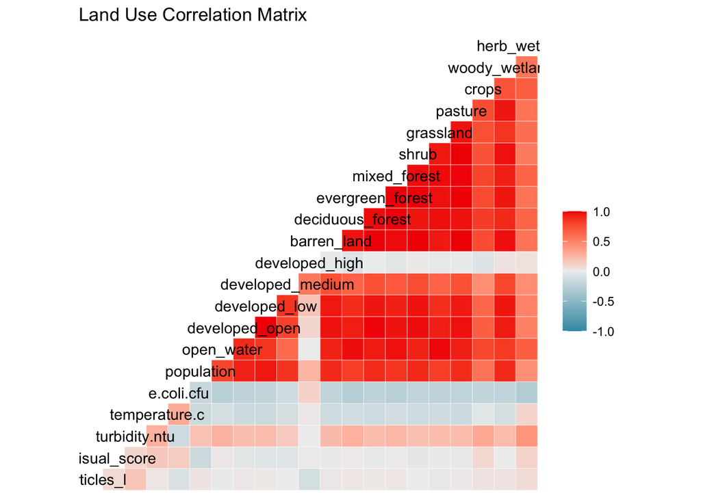

```r
athensland <- readRDS(here("data", "processed_data", "athensland.rds"))

#subset data to view in plot
athenslandcorr <- athensland %>% select(-"long",
                                        -"lat")

#land use correlation matrix
p8 <- ggcorr(athenslandcorr,
       label_alpha = TRUE) + labs(title = "Land Use Correlation Matrix")
plot(p8)
```

```r
#save figure
figure_file = here("results","landmatrix.png")
ggsave(filename = figure_file, plot=p8)
```

In this plot, we are mainly looking at the row containing particles/L (the very bottom row). We do not see any strong correlations between microplastic level and local land use.

We also may want to see the variability of microplastic concentration at each individual site (rather than aggregate concentration) througout the seasons/sample dates. Let’s take a look.

# concentration at each site throughout seasons

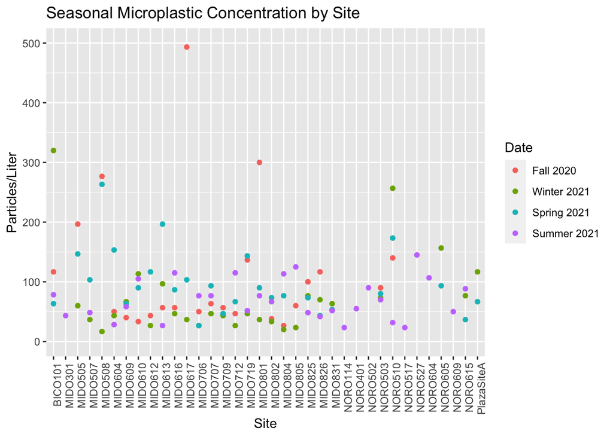

```r
p9 <- mpdata %>% ggplot(aes(x = site, y = particles_l, color = date)) +
  geom_point() + scale_color_discrete(name = "Date",
                                     breaks= c("nov_20", "feb_21", "apr_21", "july_21"),
                                     labels = c("Fall 2020", "Winter 2021", "Spring 2021", "Summer 2021")) +
  theme(axis.text.x = element_text(angle = 90, hjust=1)) +
  labs(title = "Seasonal Microplastic Concentration by Site", x = "Site", y = "Particles/Liter") + ylim(0,500) #removing outliers to better visualize majority of concentrations

plot(p9)
```

```r
#save figure
figure_file = here("results","seasonalconc_bysite.png")
ggsave(filename = figure_file, plot=p9)
```

In this plot, we see that some sites experienced small differences in concentration between seasons, while other experienced large differences between seasons.

Similarly, let’s see if there are any distictions between watersheds, since we can group the sample sites based on what watershed they are located in.

# View concentration by watershed

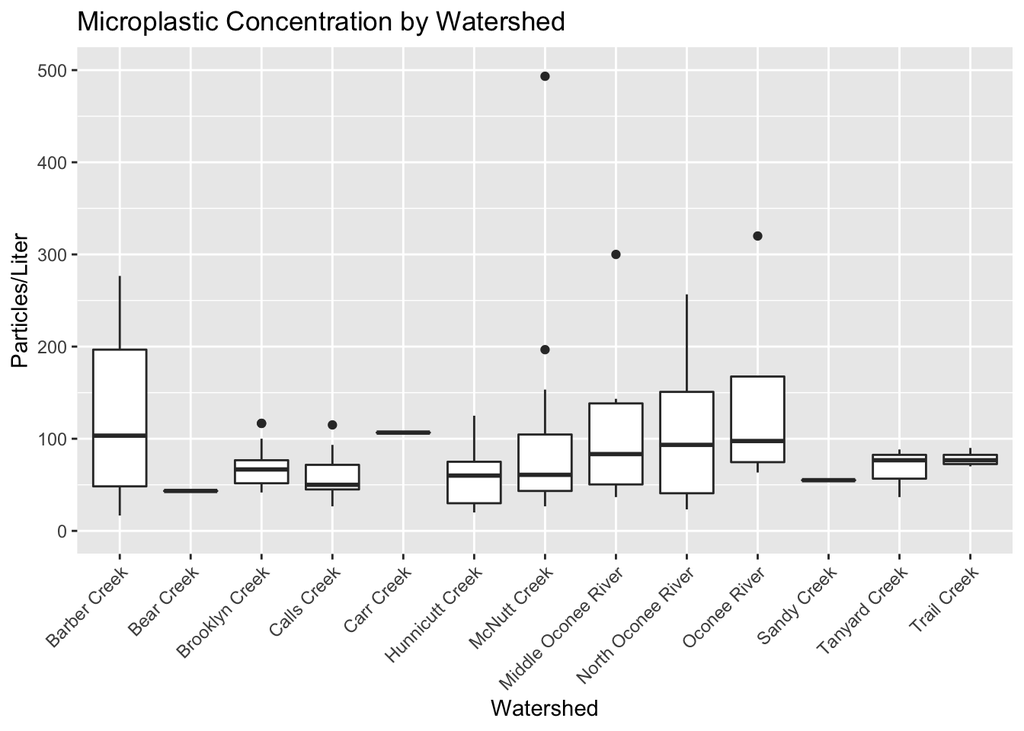

```r
p10 <- mpdata %>% ggplot(aes(x = watershed, y = particles_l, color = )) +
  geom_boxplot()  +
  theme(axis.text.x = element_text(angle = 45, hjust=1)) +
  labs(title = "Microplastic Concentration by Watershed", x = "Watershed", y = "Particles/Liter") + ylim(0,500)

plot(p10)
```

```r
#save figure
figure_file = here("results","conc_bywatershed.png")
ggsave(filename = figure_file, plot=p10)
```

A few watersheds exhibit more variation/range in microplastic level than other watersheds. This also may be due to the number of sites located in each watershed (some watersheds contain very few sites while others contain many). It may be useful to include an “n =” on this graph in the future.

Instead of viewing a dot/point for each sample data, let’s view the concentrations at each site throughout the year as a boxplot to visualize variability, averages, etc.

# Boxplot for individual sites throughout season

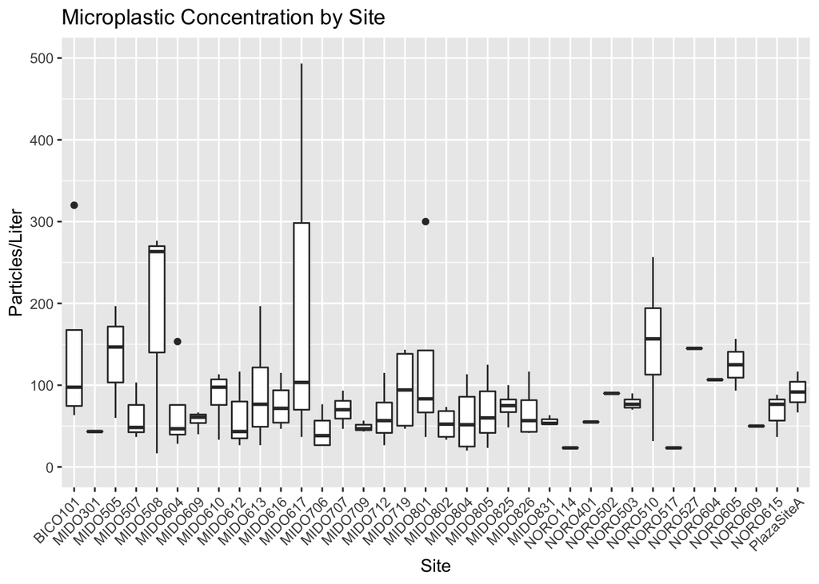

```r
p11 <- mpdata %>% ggplot(aes(x = site, y = particles_l, color = )) +
  geom_boxplot()  +
  theme(axis.text.x = element_text(angle = 45, hjust=1)) +
  labs(title = "Microplastic Concentration by Site", x = "Site", y = "Particles/Liter") + ylim(0,500)

plot(p11)
```

```r
#save figure
figure_file = here("results","conc_bysite.png")
ggsave(filename = figure_file, plot=p11)
```

There are a few sites that have quite a large range of values, though the majority of the sites have a small to moderate range. It must also be noted that not all sample sites were accounted for at each sample date. So, some sites may only have 1 or 2 observations, while other sites may have 4 observations.

I want to visualize the change (or lack of change) in MP concentration over time. However, that is a lot to take in looking at individual sites. Let’s view the average concentrations in each watershed for each sample date. Then, we can look at those watershed averages over time throughout the study period.

# concentration over time by watershed

```r
# calculate mean concentration in each watershed for each sample date
mean_data <- group_by(mpdata, watershed, date) %>%
             summarise(particles_l = mean(particles_l, na.rm = TRUE))
```

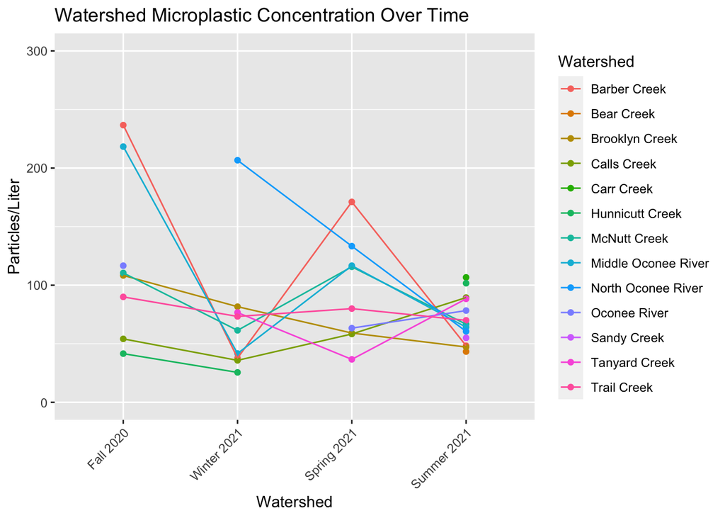

```r
# create plot using mean data
p12 <- mean_data %>% ggplot(aes(x = date, y = particles_l, color = watershed, group = watershed)) +
  geom_point() + geom_path() + scale_color_discrete(name = "Watershed")+
  theme(axis.text.x = element_text(angle = 45, hjust=1)) +
  labs(title = "Watershed Microplastic Concentration Over Time", x = "Watershed", y = "Particles/Liter") + scale_x_discrete(labels=c("Fall 2020",
                            "Winter 2021",
                            "Spring 2021",
                            "Summer 2021"))+
  ylim(0,300) #removing outliers to better visualize majority of concentrations

plot(p12)
```

```r
#save figure
figure_file = here("results","watershed_overtime.png")
ggsave(filename = figure_file, plot=p12)
```

Looking at the data this way, we do see somewhat of a pattern. It appears that the range of microplastic concentration decreases from Fall 2020 to Summer 2021. This may be due to some particularly large outliers in the earlier sample dates. Also, we may consider human error. Since I counted these microplastics myself, it may be that I initially over-counted, including false positives (particles that I mistook for microplastics, when they may have been organic matter, etc). Essentially, methods may have improved/refined over time.

Going forward, I should think about whether to keep or remove the watersheds that were only sampled in the last (July) sampling. Note: I also see that some watershed are missing intermediate data points and are not connected. Would we want to connect and skip over a season, or leave them unconnected (looking at Oconee River)?